# Counting word

## Conceptual and logical model

Since we have to count the frequencies of the words inside a text the more economic way in terms of complexity is too save each word as a key of a dictionary and update its value each time we find that word. Moreover since we used as an example the english version of the bible we will remove the most common english (stopwords). The final result will be a json containing just one dictionary in which there are the words as key and the frequency as value, we perfomed some data visualization in order to understand which are the most popular words in the bible.

## Structure of the pipeline

### Stages:

- Ingestion of the input file: load the raw data.
- Pre-process the data: some basic operations to clean and prepare the file to be analyzed as check the encoding, remove puncuation, remove stopwords, transoform all the words in lowercase and split them by spaces.
- process: create a dictionary having words (str) as keys and associated frequencies (int) as values.
- delivery of the output: create a csv file with word-occurencies pairs and (optional) a related barplot with frequencies.

### Batch or Stream

Depending on which process we choose, the major change will happen at the delivery phase (stream->json, batch->csv and graph). That's because in stream processing the output needs to be updated more frequently.

### Scaling procedures:

- vertical: augmented computer power
- horizontal: stages divided among different machines

### Examples:

- STREAM: live report of online election
- BATCH: count words in the comment section (customer satisfaction)

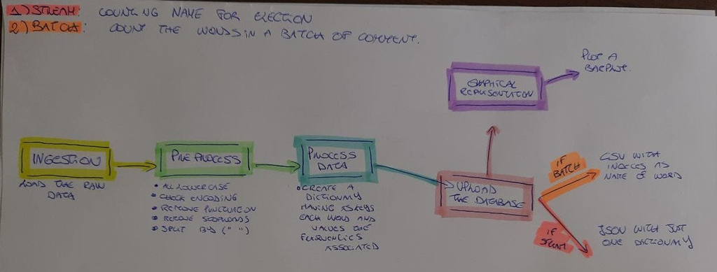

```python
from IPython.display import Image
Image(filename='pipeline.jpg')
```

## Counting the words of the Bible

```python
import nltk
from nltk.tokenize import RegexpTokenizer
import pandas as pd
import numpy as np
import seaborn as sns
import matplotlib.pyplot as plt
from copy import deepcopy
with open("bible.txt") as bible:
    stopwords = set(["i", "me", "my", "myself", "we", "our", "ours", "ourselves", "you","upon","also","thou","o","us","ye","upon","thy","among", "your", "yours", "yourself","unto", "shall","yourselves", "he", "him", "his", "himself", "she", "her", "hers", "herself", "it", "its", "itself", "they", "them", "their", "theirs", "themselves", "what", "which", "who", "whom", "this", "that", "these", "those", "am", "is", "are", "was", "were", "be", "been", "being", "have", "has", "had", "having", "do", "does", "did", "doing", "a", "an", "the", "and", "but", "if", "or", "because", "as", "until", "while", "of", "at", "by", "for", "with", "about", "against", "between", "into", "through", "during", "before", "after", "above", "below", "to", "from", "up", "down", "in", "out", "on", "off", "over", "under", "again", "further", "then", "once", "here", "there", "when", "where", "why", "how", "all", "any", "both", "each", "few", "more", "most", "other", "some", "such", "no", "nor", "not", "only", "own", "same", "so", "than", "too", "very", "s", "t", "can", "will", "just", "don", "should","n", "now"])
    books = {}
    for row in bible:
        name_book = row.find(" ")
        name = row[:name_book].strip()
        if name.isdigit():
            name_book2 = row.find(" ", name_book+1)
            name = row[name_book:name_book2].strip()
        colum_in = row.find(":")
        while row[colum_in+1].isdigit():
            colum_in +=1
        row_text = row[colum_in+1:].strip()
        if name not in books:
            books[name]= {}
        tokenizer = RegexpTokenizer(r'\w+')
        list_of_words = tokenizer.tokenize(row_text)
        for word in list_of_words:
            word = word.lower()
            if word not in stopwords:
                if word not in books[name] :
                    if word[:-1] in books[name]:
                        books[name][word[:-1]]+=1
                    else:
                        books[name][word]=1
                else:
                    books[name][word]+=1
def barplot(book, thresold = 100):
    word = []
    freq = []
    for key in book:
        if book[key]>thresold:
            word.append(key)
            freq.append(book[key])
    df = pd.DataFrame()
    df["words"] = word
    df["freq"] = freq
    df = df.sort_values(by="freq", ascending=False)
    fig=plt.figure(figsize=(20,20))
    sns.barplot(y='words',
                x="freq", data=df)
    plt.savefig("bible.png")
    plt.show()
```

```python
entire_bible = deepcopy(books)
total_books = list(books.keys())
total_books[0:4]
```

```
['Genesis', 'Exodus', 'Leviticus', 'Numbers']
```

```python
entire_bible["Genesis"]
```

```
{'beginning': 5,
 'god': 238,
 'created': 11,
 'heaven': 33,
 'earth': 121,
 'without': 9,
 'form': 1,
 'void': 1,
 'darkness': 5,
 'face': 53,
 'deep': 6,
 'spirit': 5,
 'moved': 2,
 'waters': 32,
 'said': 478,
 'let': 93,
 'light': 14,
 'saw': 57,
 'good': 53,
 'divided': 10,
 'called': 98,
 'day': 138,
 'night': 31,
 'evening': 10,
 'morning': 20,
 'first': 17,
 'firmament': 9,
 'midst': 6,
 'divide': 5,
 'made': 73,
 'second': 14,
 'gathered': 15,
 'together': 18,
 'one': 78,
 'place': 52,
 'dry': 4,
 'land': 193,
 'appear': 2,
 'gathering': 2,
 'seas': 2,
```

[output cut: 946 more lines]

```
 'certainly': 5,
 'behind': 6,
 'stricken': 2,
 'manner': 9,
 'waxed': 3,
 'pleasure': 1,
 'laugh': 4,
 'hard': 3,
 'denied': 1,
 'nay': 6,
 'command': 3,
 'household': 8,
 'justice': 1,
 'judgment': 1,
 ...}
```

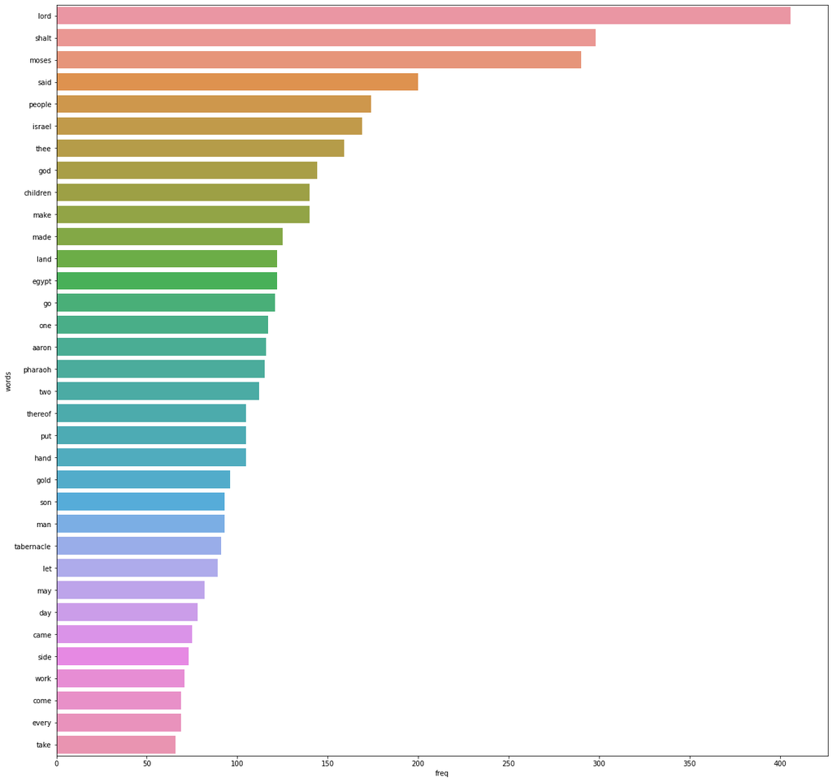

```python
barplot(entire_bible["Exodus"], 60) # the 60 is the thresold minimun to be plotted.
```

# Create just one dictionary

We create just one dictionary so it will be easier to update:

```python
all_in_one = {}
for book in entire_bible:
    for word in entire_bible[book]:
        if word not in all_in_one:
            all_in_one[word]=1
        else:
            all_in_one[word]+=entire_bible[book][word]
```

```python
def from_text_to_dict(text, save_on= None):
    "if you already have a dict, pass it with the  \
     parameters save_on if is a file must be .txt"
    import nltk
    from nltk.tokenize import RegexpTokenizer
    stopwords = set(["i", "me", "my", "myself", "we", "our", "ours", "ourselves", "you","upon","also","thou","o","us","ye","upon","thy","among", "your", "yours", "yourself","unto", "shall","yourselves", "he", "him", "his", "himself", "she", "her", "hers", "herself", "it", "its", "itself", "they", "them", "their", "theirs", "themselves", "what", "which", "who", "whom", "this", "that", "these", "those", "am", "is", "are", "was", "were", "be", "been", "being", "have", "has", "had", "having", "do", "does", "did", "doing", "a", "an", "the", "and", "but", "if", "or", "because", "as", "until", "while", "of", "at", "by", "for", "with", "about", "against", "between", "into", "through", "during", "before", "after", "above", "below", "to", "from", "up", "down", "in", "out", "on", "off", "over", "under", "again", "further", "then", "once", "here", "there", "when", "where", "why", "how", "all", "any", "both", "each", "few", "more", "most", "other", "some", "such", "no", "nor", "not", "only", "own", "same", "so", "than", "too", "very", "s", "t", "can", "will", "just", "don", "should","n", "now"])
    if "." in text:
        with open(text) as file:
            text = str(set(file))
    if save_on == None:
        res = {}
    else:
        res = save_on
    tokenizer = RegexpTokenizer(r'\w+')
    list_of_words = tokenizer.tokenize(text)
    for word in list_of_words:
        word = word.lower()
        if word not in stopwords:
            if word not in res:
                res[word]=1
            else:
                res[word]+=1
    return res
```

```python
count = from_text_to_dict("sample-text-file.txt", all_in_one)
import json
with open("count_word.json", "w", encoding="utf-8") as w:
    json.dump(count, w)
with open("count_word.json", "r", encoding="utf-8") as r:
    count =json.load(r)
```

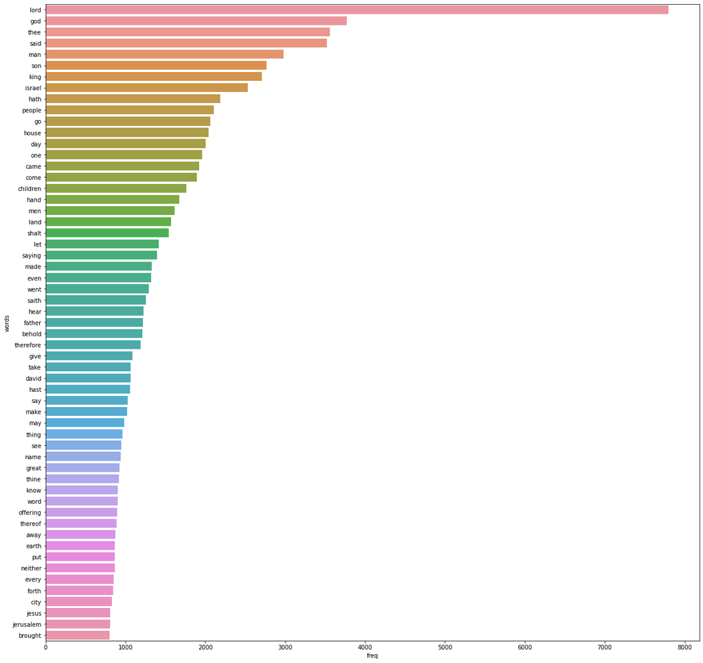

```python
barplot(count, 800)
```